# Freie Datenexploration

lexikalische Entscheidungsaufgabe

Daniela Palleschi

Humboldt-Universität zu Berlin

2023-07-04

# Heutige Ziele

Diese Woche werden wir…

- die Aufgaben für Bericht 2 durchgehen
- einige Daten frei erkunden
- verschiedene Quarto-Ausgabeformate besprechen (wenn Sie Zeit haben)

## Lust auf mehr?

- Section 30 ([Visualising relationsips](https://r4ds.hadley.nz/data-visualize.html#visualizing-relationships)) in Wickham et al. (o. J.)
- Ch. 4 ([Representing summary statistics](https://psyteachr.github.io/introdataviz/representing-summary-statistics.html)) in Nordmann et al. (2022)

# Bericht Feedback

## Mentimeter 1

Gehen Sie auf menti.com und geben Sie den Code 1643 4313 ein, oder scannen Sie den QR-Code:

[figure not shown]

## Mentimeter 2

Gehen Sie auf menti.com und geben Sie den Code 4154 0840 ein, oder scannen Sie den QR-Code:

[figure not shown]

# Einrichtung

## Pakete

```r
pacman::p_load(tidyverse,
               here,
               knitr,
               kableExtra,
               languageR)
```

## Daten

```r
df_lexdec <- languageR::lexdec %>%
  mutate(RT = exp(RT)) # back-transform log RTs to milliseconds
```

# Wiederholung: Bericht 2

```r
library(introdataviz)
```

```r
df_biondo <- read_csv(here("daten", "Biondo_etal_2021_bericht2.csv")) %>%
  janitor::clean_names()
```

```r
df_biondo_long <-
  df_biondo %>%
  pivot_longer(
    cols = c(first_pass, regression_path, total_time),
    names_to = "measure",
    values_to = "time"
  ) %>%
  relocate(measure, time, .after=gramm)
```

## Erzeugen einer zusammenfassenden Tabelle

- versuchen, Tabelle 1 zu reproduzieren

```r
df_biondo %>%
  drop_na() %>%
  filter(region == "verb", adverb_time != "none") %>%
  summarise(N = n(),
            mean = mean(total_time),
            sd = sd(total_time),
            .by = c(region, adverb_time,verb_tense)) %>%
  arrange(region, adverb_time) %>%
  kable(col.names = c(
    "Region", "Adverb time", "Verb tense", "N", "Mean total reading time", "SD"
  ))
```

| Region | Adverb time | Verb tense | N | Mean total reading time | SD |
| --- | --- | --- | --- | --- | --- |
| verb | Future | Future | 948 | 602.7521 | 411.5918 |
| verb | Future | Past | 945 | 628.4836 | 423.4241 |
| verb | Past | Past | 953 | 556.7817 | 366.4723 |
| verb | Past | Future | 949 | 642.0242 | 433.0259 |

## Rekonstruieren einer Handlung

- Was wird benötigt, um diese Darstellung zu reproduzieren?
  - Welche Variable(n) sind auf den Achsen abgebildet?
  - Welche Variable(n) befinden sich in der Legende?

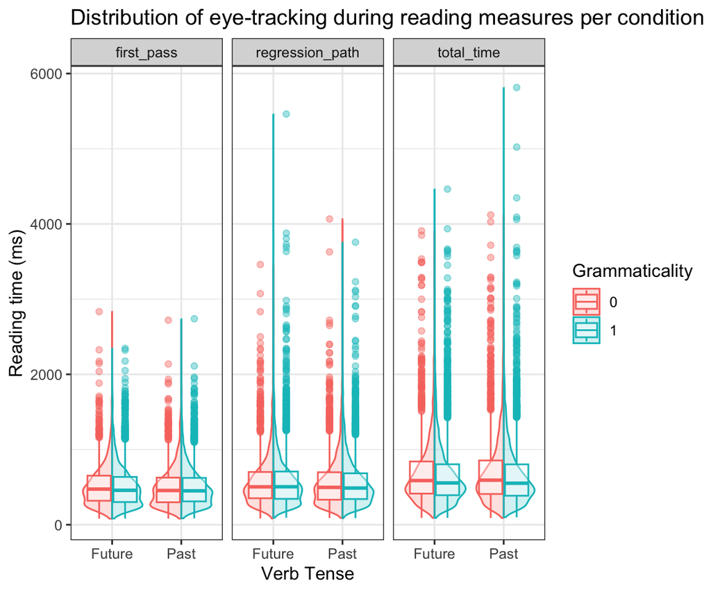

Abbildung 1: A split-violin boxplot

# lexikalische Entscheidungsaufgabe

- Teilnehmer entscheiden, ob ein Wort ein echtes Wort oder ein Unwort ist

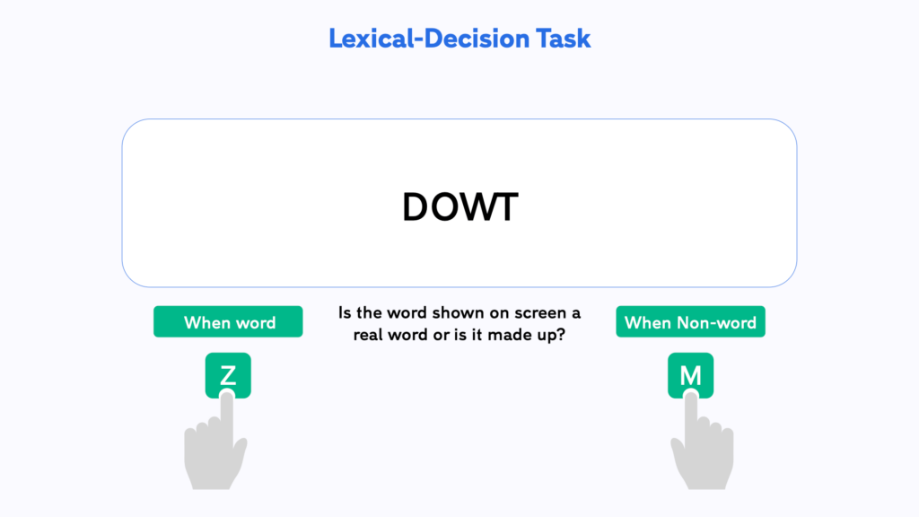

# `languageR`

## `lexdec` Datenrahmen

- der `lexdec`-Datensatz enthält Antworten (Variable `Correct`) für eine lexikalische Entscheidungsaufgabe in Englisch
- lexikalische Entscheidungsaufgabe: dem Teilnehmer wird ein einzelnes Wort präsentiert, und er gibt durch Tastendruck an, ob das Wort ein echtes Wort oder ein Nicht-Wort ist
- eine Liste einiger der Variablen ist in Tabelle 2 enthalten

Tabelle 2: Data dictionary for `df_lexdec`: Lexical decision latencies elicited from 21 subjects for 79 English concrete nouns, with variables linked to subject or word.

| variable | description |
| --- | --- |
| Subject | a factor for the subjects |
| RT | a numeric vector for reaction times in milliseconds |
| Trial | a numeric vector for the rank of the trial in the experimental list. |
| Sex | a factor with levels F (female) and M (male). |
| NativeLanguage | a factor with levels English and Other, distinguishing between native and nonnative speakers of English |
| Correct | a factor with levels correct and incorrect coding whether the word was correctly responded to as a word rather than a nonword. |
| PrevType | a factor with levels nonword and word coding whether the item presented at the preceding trial was a word or a nonword. |
| PrevCorrect | a factor with levels correct and incorrect coding whether the preceding item elicited a correct response. |
| Word | a factor with 79 words as levels. |
| Frequency | a numeric vector with logarithmically transformed lemma frequencies as available in the CELEX lexical database. |
| Length | a numeric vector for the word's length in letters. |
| Class | a factor for the semantic category of the word's referent, with levels animal and plant. |
| Complex | a factor coding morphological complexity with levels complex and simplex. |
| meanRT | a numeric vector for the by-item mean reaction time averaged over subjects. |
| BNCcRatio | a numeric vector with the log of the ratio of the (absolute) frequencies in the context-governed and written parts of the British National Corpus, normalized for the differences in corpus size. |
| BNCdRatio | a numeric vector with the log of the ratio of the (absolute) frequencies in the demographic and written parts of the British National Corpus, normalized for the differences in corpus size. |

## Aufgabe

1. Stellen Sie sich vor, Sie hätten die Daten von `lexdec` gesammelt
   1. Wie würde Ihre Ergebnisvariable lauten (das, was Sie messen wollen)?
   2. Welche Vorhersagen könnten Sie für diese Variable treffen (z. B. würden Sie Unterschiede in Ihrer Ergebnisvariable zwischen zwei Gruppen von Personen erwarten? zwischen verschiedenen Wortarten?)
2. Untersuchen Sie die Daten.
   1. Fassen Sie die Daten auf der Grundlage Ihrer Vorhersagen aus 1b zusammen.
   2. Erstellen Sie Diagramme der Daten, um den Vergleich, der Sie interessiert, zu visualisieren.
   3. Versuchen Sie, die Daten zu interpretieren, um zu sehen, ob Ihre Vorhersagen zutreffen.

# Ausgabeformate

- Wir erinnern daran, dass Quarto verschiedene Dateiformate ausgeben kann
- Dokumente
  - html
  - PDF
  - MS Word
- Folien
  - html-Folien
  - PowerPoint-Folien
  - Beamer (LaTeX)

# Dokumente

## MS Word

- Lassen Sie uns zunächst versuchen, ein MS Word-Dokument zu erstellen
1. Ändern Sie `format` in `docx`

```r
title: "Datenvisualisierung 2"
subtitle: "Darstellung der zusammenfassenden Statistik"
author: "Daniela Palleschi"
date: "`r Sys.Date()`"
format:
  docx:
    toc: true
    number-sections: true
```

2. Rendern und prüfen

# Folien

- Folien werden mit einem Hashtag `#` gekennzeichnet
  - Während dies in einem Dokument eine neue Überschrift einleiten würde, würde es in einer Präsentation eine neue Folie einleiten.

## revealjs

- let’s try first creating a HTML slides with `revealjs`
1. change `format:` to `revealjs`

```r
title: "Datenvisualisierung 2"
subtitle: "Darstellung der zusammenfassenden Statistik"
author: "Daniela Palleschi"
date: "`r Sys.Date()`"
format:
  revealjs:
    toc: true
    number-sections: true
```

2. Rendern und prüfen

## PowerPoint

```r
title: "Datenvisualisierung 2"
subtitle: "Darstellung der zusammenfassenden Statistik"
author: "Daniela Palleschi"
date: "`r Sys.Date()`"
format:
  pptx:
    toc: true
    number-sections: true
```

2. Rendern und prüfen

# Aufgabe

1. Wählen Sie Ihr bevorzugtes Ausgabeformat (oder eines, das Sie üben möchten).
2. Versuchen Sie, einen Bericht über die `lexdec`-Daten in diesem Format zu erstellen (es gibt hier keine Erwartungen, versuchen Sie, was immer Sie wollen).

# Session Info

Hergestellt mit R version 4.3.0 (2023-04-21) (Already Tomorrow) und RStudioversion 2023.3.0.386 (Cherry Blossom).

# Literaturverzeichnis

Baayen, R. H. (2008). *Analyzing Linguistic Data: A Practical Introduction to Statistics Using R*.

Nordmann, E., McAleer, P., Toivo, W., Paterson, H., & DeBruine, L. M. (2022). Data Visualization Using R for Researchers Who Do Not Use R. *Advances in Methods and Practices in Psychological Science*, *5*(2), 251524592210746. https://doi.org/10.1177/25152459221074654

Wickham, H., Çetinkaya-Rundel, M., & Grolemund, G. (o. J.). *R for Data Science* (2. Aufl.). https://r4ds.hadley.nz/

Datenexploration